# DACSS 697D Post 2

text as data

homework

Assignment 2 for DACSS 697D Course ‘Text as Data’: “Webscraping using APIs”

Kristina Becvar https://www.kristinabecvar.com  
02-19-2022

## Overview of Weeks 3 and 4

### Week 3 Learning Curve in Webscraping using CSS

In Week 3, working with the css selector has proven frustrating. After building confidence in using the CSS Diner tutorial, working through the colab tutorial was less empowering. First, because the SelectorGadget tool is not available to be used in Chrome when logged in to the UMass environment due to blocking of the Chrome Store. So in the tutorial, I was able to find where the “#tablepress-73” was by inspecting the page but I would not have known how to find that to import it into R unless I was given that information, so I clearly need to understand this process better.

### Week 3 API Usage

Week 3 included a welcome introduction to scraping data using an api, and specifically using the New York Times api was exciting given I have a research project using New York Times data that I have been conducting manually using PDF versions of the articles being used. However, I tried using the material to use a different api - one from opensecrets.org. After getting the api key, I started trying to see if I could apply some of the skills learned in the lab to search for information on lobby groups and data related to lobby groups with a focus on veteran issues. However, I ran into issues with this api, so I returned to using the New York Times api for information involving a new research topic for this week’s blog. I hope to return to troubleshooting my issues with the opensecrets.org api later.

### Week 4 Natural Language Processing

Week 4 materials in NLP are extremely valuable and interesting to me. Unfortunately, due to learning curve issues, frustration, and the simple volume of information I am learning at once this semester, I have just scratched the surface of the NLP skills we are learning in this blog post. I look forward to developing them further as the semester goes on.

### Frustration

I could not get all of the demonstrative code from all of the notebook tutorials to work on my own RStudio. Specifically, I realized that simply installing Python was not enough, and through I read that I needed to install the Anaconda platform for NLP in the tutorial, I had no idea how to functionally execute this task. Given my absolute absence of knowledge of Python and anything related, this was a long day of trying to catch up with little success. After over 20 hours of messing around with various help sites and trial and error on this, I was referred to the ‘spacyr’ package and its’ documentation by a classmate. This helped immensely, and after successfully getting the Miniconda and dependent actions completed, I was able to move forward.

```r
library(httr); library(jsonlite)
library(dplyr)
library(quanteda)
library(tidyverse)
library(tidytext)
library(cleanNLP)
library(rvest)
```

## Work Content for Weeks 3 and 4

### Trouble Using The opensecrets.org API

I know from the API documentation that the Committee on Veterans’ Affairs is listed with committee code “HVET” (House) as well as “SVET” (Senate). The House Armed Services committee is coded “HARM”.

I am looking for data from the 116th U.S. Congress, convened on January 3, 2019 and ending on January 3, 2021.

So I start with “GET” and my api call for the House Committee on Veterans Affairs, but this is not working. After literally hours of troubleshooting, I realized my error was that I failed to put a (’) mark at the beginning and end of my api call. It is so numbingly obvious now that I’ve seen it. Coding is nothing if not time consuming and absolutely aggravating. I’m beginning to feel like a real coder after the last 2 days and hours of work over a silly apostrophe!

### Anyway, Back To The Project…

```r
cnlp_init_udpipe()
```

```r
HVET <- GET('https://www.opensecrets.org/api/?method=congCmteIndus&congno=116&indus=F10&cmte=HVET&apikey=3f183582e16c4fff025509c65828bfa4&output=json')

names(HVET)
```

```
 [1] "url"         "status_code" "headers"     "all_headers"
 [5] "cookies"     "content"     "date"        "times"
 [9] "request"     "handle"
```

```r
#HVET_r <- fromJSON(rawToChar(HVET$content))
#names(HVET_r)
#HVET_r$fault
```

I continue to receive errors indicating a lexical error, then an invalid apikey. I am struggling to understand why my api key is not working here. Since I cannot do through another delve into troubleshooting and understand how this api has returned different results, I will instead go back to the New York Times api and pull my own text relevant to another new project.

### New York Times Article Search for last 7 days on Ukraine

Finally, I can move a bit further after successfully retrieving data using my NYT api:

```r
ukraine <- GET('https://api.nytimes.com/svc/search/v2/articlesearch.json?begin_date=20220213&end_date=20220220&q=ukraine&api-key=GTp3efxVZiGO75Iox9uZJ8ZTjIMjDWsM')

names(ukraine)
```

```
 [1] "url"         "status_code" "headers"     "all_headers"
 [5] "cookies"     "content"     "date"        "times"
 [9] "request"     "handle"
```

### Now I can take the step of transforming JSON objects into R objects:

```r
ukraine_r <- fromJSON(rawToChar(ukraine$content))
names(ukraine_r)
```

```
[1] "status"    "copyright" "response"
```

### And look at the response and lead paragraph headers:

```r
#ukraine_r$response
```

```r
ukraine_r$response$docs$lead_paragraph
```

```
 [1] "Follow live coverage on Russiaâ\200\231s invasion of Ukraine."
 [2] "A day before Ukraine announced its Defense Ministry and banking servers had been hacked, our video team toured the countryâ\200\231s Cybercommand Center, where officials have been preparing for this scenario for years."
 [3] "WASHINGTON â\200” When Wang Yi, Chinaâ\200\231s foreign minister, called on Saturday for talks to resolve the crisis in Europe, he said Ukraineâ\200\231s sovereignty should be â\200œrespected and safeguardedâ\200\235 â\200” but also sided with Russia in saying that NATO enlargement was destabi…
 [4] "MUNICH â\200” When President Biden declared on Friday he was convinced President Vladimir V. Putin of Russia had decided to attack Ukraine â\200œin the coming week, in the coming days,â\200\235 the skeptics among American allies suddenly fell quiet. Hours before, Mr. Biden had informed them th…
 [5] "Vladimir Putin may still order an invasion of Ukraine, as President Biden said yesterday. Putin has long been obsessed with Ukraine, viewing it as part of Russiaâ\200\231s immediate orbit. And more than 150,000 Russian troops remain ready to pour over the border if Putin gives the order."
 [6] "As Russian troops are dispatched to Ukraineâ\200\231s borders, the threat of a major assault on the country continues to escalate. Ukrainian soldiers stand guard at possible points of invasion, including sections of irradiated zones near Chernobyl. The United States has sent troops to NATO cou…
 [7] "MARIUPOL, Ukraine â\200” Paramilitary groups are actively preparing for a Russian invasion near Ukraineâ\200\231s front line with Russia-backed separatists."
 [8] "Big American and European companies operating on the ground in Ukraine said Friday that they had contingency plans at the ready in case of a Russian invasion but so far had not ordered the relocation of employees."
 [9] "KYIV, Ukraineâ\200” Pavlo Kaliuk, a freelance property broker in Ukraineâ\200\231s capital, used to sell and rent properties to clients from the United States, France, Germany and Israel. Then in November, when Russia first began posting troops along the countryâ\200\231s border, the deals qui…
[10] "The New York Times traveled with a paramilitary group that says it refuses to leave the front lines in Ukraineâ\200\231s war in the east. But the government denies that theyâ\200\231re even there. What role can they have in a larger conflict with Russia?"
```

### And take some of the aspects of this data that are interesting to me and create a tibble:

```r
ukraine_t <- as_tibble(cbind(
          date=ukraine_r$response$docs$pub_date,
          abstract=ukraine_r$response$docs$abstract,
          lead=ukraine_r$response$docs$lead_paragraph)
)

ukraine_t
```

```
# A tibble: 10 x 3
   date         abstract                     lead
   <chr>        <chr>                        <chr>
 1 2022-02-19T~ Hereâ€™s why Ukraineâ€™s im~ "Follow live coverage on~
 2 2022-02-16T~ A day before Ukraine announ~ "A day before Ukraine an~
 3 2022-02-20T~ The Biden administration pl~ "WASHINGTON â€” When Wan~
 4 2022-02-20T~ President Vladimir V. Putin~ "MUNICH â€” When Preside~
 5 2022-02-16T~ Three explanations for the ~ "Vladimir Putin may stil~
 6 2022-02-15T~ Andrew E. Kramer, a Times M~ "As Russian troops are d~
 7 2022-02-19T~ Times journalists followed ~ "MARIUPOL, Ukraine â€” P~
 8 2022-02-18T~ Despite warnings by Western~ "Big American and Europe~
 9 2022-02-18T~ Flights have been canceled,~ "KYIV, Ukraineâ€” Pavlo ~
10 2022-02-19T~ The New York Times traveled~ "The New York Times trav~
```

### Finally, I can utilize the cleanNLP package:

```r
cnlp_init_udpipe()

annotated <- cnlp_annotate(ukraine_t$lead)
```

```
Processed document 10 of 10
```

```r
head(annotated)
```

```
$token
# A tibble: 501 x 11
   doc_id   sid tid   token  token_with_ws  lemma upos  xpos  feats
 *  <int> <int> <chr> <chr>  <chr>          <chr> <chr> <chr> <chr>
 1      1     1 1     Follow "Follow "      foll~ VERB  VB    Mood=Im~
 2      1     1 2     live   "live "        live  ADJ   JJ    Degree=~
 3      1     1 3     cover~ "coverage "    cove~ NOUN  NN    Number=~
 4      1     1 4     on     "on "          on    ADP   IN    <NA>
 5      1     1 5     Russi~ "Russiaâ€™s " Russ~ PROPN NNP   Number=~
 6      1     1 6     invas~ "invasion "    inva~ NOUN  NN    Number=~
 7      1     1 7     of     "of "          of    ADP   IN    <NA>
 8      1     1 8     Ukrai~ "Ukraine"      Ukra~ PROPN NNP   Number=~
 9      1     1 9     .      "."            .     PUNCT .     <NA>
10      2     1 1     A      "A "           a     DET   DT    Definit~
# ... with 491 more rows, and 2 more variables: tid_source <chr>,
#   relation <chr>

$document
   doc_id
1       1
2       2
3       3
4       4
5       5
6       6
7       7
8       8
9       9
10     10
```

### and the spacyr package:

```r
library(spacyr)

spacy_initialize(model="en_core_web_sm")
ukraine_parsed <- spacy_parse(ukraine_t$lead, tag=TRUE, nounphrase=TRUE, entity=TRUE, lemma=TRUE)

head(ukraine_parsed)
```

```
  doc_id sentence_id token_id    token    lemma   pos tag entity
1  text1           1        1   Follow   follow  VERB  VB
2  text1           1        2     live     live   ADJ  JJ
3  text1           1        3 coverage coverage  NOUN  NN
4  text1           1        4       on       on   ADP  IN
5  text1           1        5 Russiaâ\200 Russiaâ\200 PROPN NNP
6  text1           1        6        \231        \231 PROPN NNP
  nounphrase whitespace
1                  TRUE
2        beg       TRUE
3   end_root       TRUE
4                  TRUE
5        beg      FALSE
6        mid      FALSE
```

### Annotating Data

```r
ukraine_anno <- left_join(annotated$document, annotated$token, by = "doc_id")
head(ukraine_anno)
```

```
  doc_id sid tid      token token_with_ws      lemma  upos xpos
1      1   1   1     Follow       Follow      follow  VERB   VB
2      1   1   2       live         live        live   ADJ   JJ
3      1   1   3   coverage     coverage    coverage  NOUN   NN
4      1   1   4         on           on          on   ADP   IN
5      1   1   5 Russiaâ\200\231s   Russiaâ\200\231s  Russiaâ\200\231s PROPN  NNP
6      1   1   6   invasion     invasion    invasion  NOUN   NN
                  feats tid_source relation
1 Mood=Imp|VerbForm=Fin          0     root
2            Degree=Pos          3     amod
3           Number=Sing          1      obj
4                  <NA>          6     case
5           Number=Sing          6 compound
6           Number=Sing          1      obl
```

### And finally, beginning to summarize data from the text.

```r
library(magrittr)

nouns <- ukraine_anno %>%
  filter(upos == "NOUN") %>%
  group_by(token) %>%
  summarize(count = n()) %>%
  arrange(desc(count))

adjs <- ukraine_anno %>%
  filter(upos == "ADJ") %>%
  group_by(token) %>%
  summarize(count = n()) %>%
  arrange(desc(count))

propns <- ukraine_anno %>%
  filter(upos == "PROPN") %>%
  group_by(token) %>%
  summarize(count = n()) %>%
  arrange(desc(count))

verbs <- ukraine_anno %>%
  filter(upos == "VERB") %>%
  group_by(token) %>%
  summarize(count = n()) %>%
  arrange(desc(count))

head(nouns)
```

```
# A tibble: 6 x 2
  token          count
  <chr>          <int>
1 "invasion"         7
2 "â"                4
3 "troops"           4
4 "\u009d"           2
5 "border"           2
6 "countryâ€™s"     2
```

```r
head(adjs)
```

```
# A tibble: 6 x 2
  token     count
  <chr>     <int>
1 Russian       5
2 American      3
3 front         2
4 ready         2
5 Big           1
6 convinced     1
```

```r
head(propns)
```

```
# A tibble: 6 x 2
  token        count
  <chr>        <int>
1 Ukraine          8
2 Putin            6
3 Russia           6
4 President        5
5 Ukraineâ€™s     5
6 Biden            4
```

```r
head(verbs)
```

```
# A tibble: 6 x 2
  token        count
  <chr>        <int>
1 said             3
2 coming           2
3 preparing        2
4 â€œrespected     1
5 announced        1
6 attack           1
```

### Clean-Up Needed

The characters that carried over from the NYT api import are not easily cleaned up, though I have spent some time getting familiar with some of tools to do so. I need to spend more time getting familiar with the best options for this.

### Looking For a Word

I scratched the surface of the stringr function and looked at all of the lead paragraphs from the last week to see if there was any variation of the word “protest(s)”. Unfortunately, I did not find any instances.

```r
library(stringr)

str_match(ukraine_t$lead, " [P|p]rotest[s] ")
```

```
      [,1]
 [1,] NA
 [2,] NA
 [3,] NA
 [4,] NA
 [5,] NA
 [6,] NA
 [7,] NA
 [8,] NA
 [9,] NA
[10,] NA
```

### Creating a Wordcloud

Since I had so much background work to do this week and wanted to end up creating something visually, I wanted to start with a wordcloud. Although there is a clear need to clean up the characters, I feel like I have covered a lot of ground in the last couple of weeks. I look forward to putting it together in a more purposeful way.

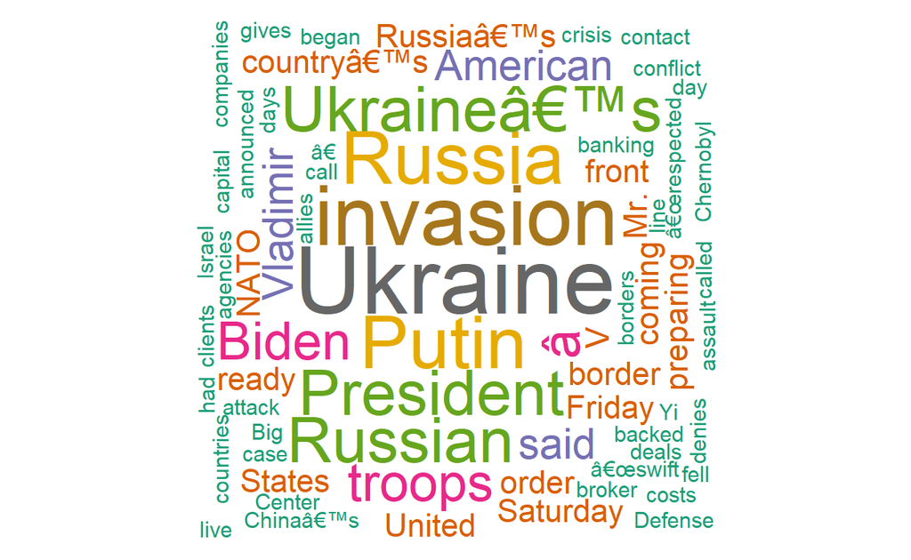

```r
library(wordcloud)
library(RColorBrewer)
library(tm)

ukraine_words <- merge(merge(merge(
  nouns,
  adjs, all = TRUE),
  propns, all = TRUE),
  verbs, all = TRUE)

set.seed(1234)

wordcloud(words = ukraine_words$token, freq = ukraine_words$count, min.freq = 1, max.words=200, random.order=FALSE, rot.per=0.35, colors=brewer.pal(8, "Dark2"))
```